# Session 3 — Inference and Multiple Linear Regression

β, p, CI · confounding · dummy variables · model building · Topics 5–6 · Lab 3

Community Medicine Workshop

## Where we are

- Session 2: one predictor → slope in units, prediction, R²
- Today: **is the slope real? is it confounded? how do we build a defensible model?**
  - Test and estimate β: **p-values and confidence intervals**
  - **Statistical vs clinical** significance
  - **Confounding** and adjustment — crude vs adjusted β
  - **Dummy coding** of categorical predictors
  - **Model-building strategies** — and why stepwise is risky

# Topic 5 — Inference for β

## Is the slope different from zero?

**H₀:** β = 0 (no linear association) **H₁:** β ≠ 0

```r
tidy(m_crude, conf.int = TRUE) |> mutate(across(where(is.numeric), ~ signif(.x, 3)))
```

```
# A tibble: 2 × 7
  term        estimate std.error statistic   p.value conf.low conf.high
  <chr>          <dbl>     <dbl>     <dbl>     <dbl>    <dbl>     <dbl>
1 (Intercept)   107         2.22      48.3 5.87e-200   103       112
2 salt_g          3.36      0.29      11.6 7.20e- 28     2.79      3.93
```

- **t = estimate ÷ standard error** — how many SEs from zero
- **p-value** — if H₀ were true, the chance of a |t| this large or larger
- **95% CI** = estimate ± ≈2 SE

## What a p-value looks like

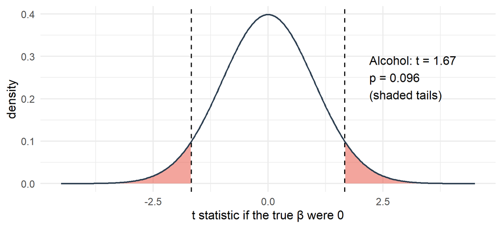

## What a p-value is — and is not

**It is**

the probability of data this extreme **if β were truly 0** (and the model assumptions hold)

**It is not**

- the probability that H₀ is true
- the size or importance of the effect
- a measure of whether the finding will replicate

## Confidence intervals say more

```r
cbind(estimate = coef(m_adj), confint(m_adj))["salt_g", ] |> round(2)
```

```
estimate    2.5 %   97.5 %
    1.80     1.21     2.39
```

- Adjusted salt effect: **1.8 mmHg per g/day** (95% CI **1.2 to 2.4**)
- A CI shows **size** *and* **precision**; p only says whether 0 is excluded
- CI excludes 0 ⇔ p < 0.05 (same information, richer format)

## Statistical vs clinical significance

```r
# A tiny true effect: 0.5 mmHg per g/day, SD of salt = 2.3 g, residual SD = 15 mmHg
tibble(n = c(50, 200, 1000, 5000, 20000)) |>
  mutate(se = 15 / (2.3 * sqrt(n)), t = 0.5 / se, p = 2 * pt(-abs(t), n - 2)) |>
  mutate(across(c(se, t), ~ round(.x, 2)), p = signif(p, 2))
```

```
# A tibble: 5 × 4
      n    se     t        p
  <dbl> <dbl> <dbl>    <dbl>
1    50  0.92  0.54 5.9 e- 1
2   200  0.46  1.08 2.8 e- 1
3  1000  0.21  2.42 1.6 e- 2
4  5000  0.09  5.42 6.20e- 8
5 20000  0.05 10.8  2.6 e-27
```

With enough people, even an effect of **0.5 mmHg per g/day** becomes “highly significant”. Ask two separate questions: **Is it unlikely to be chance?** (p) and **Is it big enough to matter for patients or programmes?** (effect size + CI).

# Topic 6 — Confounding and adjustment

## What is a confounder?

```
%%{init: {'flowchart': {'nodeSpacing': 40, 'rankSpacing': 70, 'padding': 14, 'htmlLabels': false}, 'themeVariables': {'fontSize': '22px', 'fontFamily': 'Arial, Helvetica, sans-serif'}}}%%
flowchart LR
  A["Age / BMI<br/>(confounders)"] --> S["Salt intake<br/>(exposure)"]
  A --> B["Systolic BP<br/>(outcome)"]
  S ==>|"the effect we want"| B
  classDef conf fill:#fdebd0,stroke:#e67e22,stroke-width:2px;
  classDef exp fill:#d6eaf8,stroke:#3498db,stroke-width:2px;
  classDef out fill:#fadbd8,stroke:#e74c3c,stroke-width:2px;
  class A conf; class S exp; class B out;
```

A **confounder** is associated with the exposure **and** the outcome, and is not on the causal path between them. Ignoring it **mixes** its effect into the crude estimate.

## In our data: older, heavier people eat more salt

```r
cc |> select(salt_g, sbp, age, bmi) |>
  pivot_longer(c(age, bmi), names_to = "confounder", values_to = "value") |>
  ggplot(aes(value, salt_g)) +
  geom_point(alpha = .25, colour = col_blue) +
  geom_smooth(method = "lm", colour = col_red, formula = y ~ x) +
  facet_wrap(~ confounder, scales = "free_x", labeller = as_labeller(c(age = "Age (years)", bmi = "BMI (kg/m²)"))) +
  labs(x = NULL, y = "Salt (g/day)")
```

Age and BMI also raise SBP directly. So part of the crude salt–SBP slope is **really age and BMI**.

## In our data: older, heavier people eat more salt

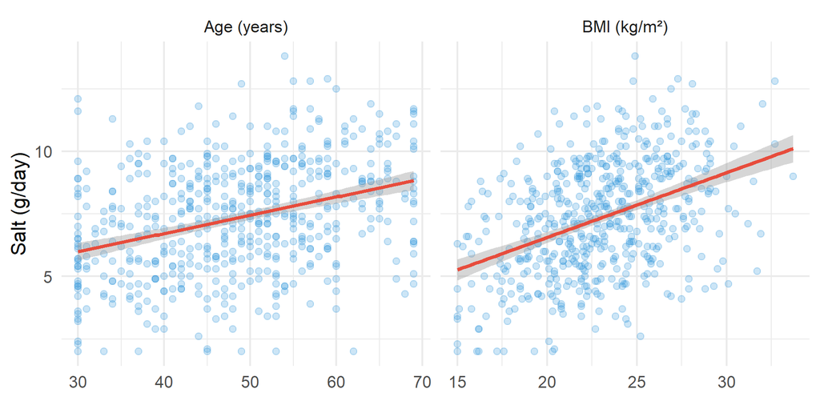

## Crude vs adjusted β

```r
m_crude <- lm(sbp ~ salt_g, data = cc)
m_adj   <- lm(sbp ~ salt_g + age + bmi + sex + residence + education +
                tobacco + alcohol + phys_act, data = cc)

c(crude = coef(m_crude)[["salt_g"]], adjusted = coef(m_adj)[["salt_g"]])
```

```
   crude adjusted
3.357640 1.799679
```

```r
100 * (coef(m_crude)[["salt_g"]] - coef(m_adj)[["salt_g"]]) / coef(m_crude)[["salt_g"]]   # % change
```

```
[1] 46.40047
```

The salt β shrinks from **3.4** to **1.8** mmHg per g/day — **46%** of the crude association was confounding. (Rule of thumb: ≥10% change ⇒ the variable matters as a confounder.)

## Which variable moved it? Add them one at a time

```r
steps <- list(
  "Crude"        = "salt_g",
  "+ age"        = c("salt_g", "age"),
  "+ BMI"        = c("salt_g", "age", "bmi"),
  "+ sex"        = c("salt_g", "age", "bmi", "sex"),
  "+ residence, education" = c("salt_g", "age", "bmi", "sex", "residence", "education"),
  "+ tobacco, alcohol, activity" = c("salt_g", "age", "bmi", "sex", "residence", "education",
                                     "tobacco", "alcohol", "phys_act")
)
path <- map_dfr(steps, \(v) tidy(lm(reformulate(v, "sbp"), cc), conf.int = TRUE) |> filter(term == "salt_g"), .id = "model") |>
  mutate(model = fct_inorder(model))

ggplot(path, aes(estimate, fct_rev(model))) +
  geom_pointrange(aes(xmin = conf.low, xmax = conf.high), colour = col_navy) +
  geom_vline(xintercept = 0, linetype = "dashed") +
  labs(x = "β for salt (mmHg per g/day), 95% CI", y = NULL)
```

## Which variable moved it? Add them one at a time

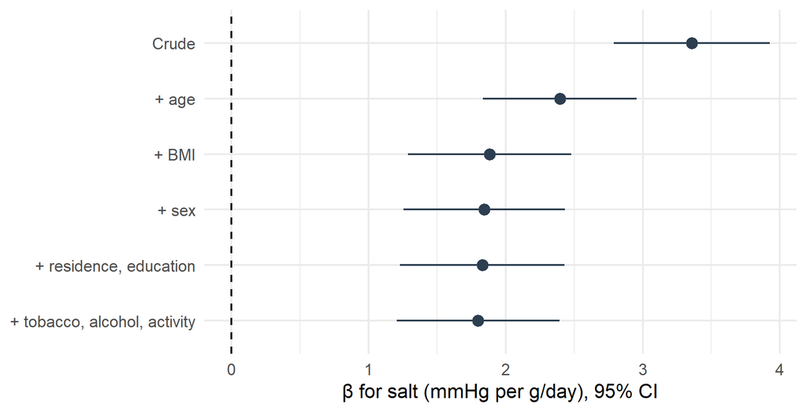

## Interpreting adjusted coefficients

```r
tbl_regression(m_adj, intercept = FALSE) |> bold_labels()
```

## Interpreting adjusted coefficients

| **Characteristic** | **Beta** | **95% CI** | **p-value** |
| --- | --- | --- | --- |
| salt_g | 1.8 | 1.2, 2.4 | <0.001 |
| age | 0.63 | 0.50, 0.75 | <0.001 |
| bmi | 0.88 | 0.52, 1.2 | <0.001 |
| sex |  |  |  |
| Female | — | — |  |
| Male | 3.8 | 1.3, 6.3 | 0.003 |
| residence |  |  |  |
| Urban | — | — |  |
| Rural | -0.29 | -3.0, 2.4 | 0.8 |
| education |  |  |  |
| No schooling | — | — |  |
| Primary | -0.85 | -4.6, 2.9 | 0.7 |
| Secondary | -1.5 | -5.4, 2.4 | 0.4 |
| Graduate+ | 0.25 | -3.8, 4.3 | >0.9 |
| tobacco |  |  |  |
| No | — | — |  |
| Yes | 3.1 | 0.46, 5.6 | 0.021 |
| alcohol |  |  |  |
| No | — | — |  |
| Yes | 2.5 | -0.44, 5.4 | 0.10 |
| phys_act |  |  |  |
| low | — | — |  |
| moderate | -3.4 | -6.3, -0.56 | 0.019 |
| high | -5.0 | -7.9, -2.1 | <0.001 |

Abbreviation: CI = Confidence Interval

## “Holding the others constant”

**Adjusted β for salt = 1.8:** *compare two people of the **same age, BMI, sex, residence, education, tobacco, alcohol and activity** — the one who eats 1 g/day more has, on average, 1.8 mmHg higher SBP.*

- “Adjusted for” ≠ “removed”: the model only removes **measured** confounders, assuming a **linear, additive** structure
- Unmeasured confounding (family history, stress, measurement error in salt) can remain

## Confounding can even reverse a story: education

```r
edu <- bind_rows(
  Crude    = tidy(lm(sbp ~ education, cc), conf.int = TRUE),
  Adjusted = tidy(m_adj, conf.int = TRUE),
  .id = "model") |> filter(str_detect(term, "^education")) |>
  mutate(term = str_remove(term, "education"), term = factor(term, c("Primary", "Secondary", "Graduate+")))

ggplot(edu, aes(estimate, term, colour = model)) +
  geom_pointrange(aes(xmin = conf.low, xmax = conf.high), position = position_dodge(.5)) +
  geom_vline(xintercept = 0, linetype = "dashed") +
  scale_colour_manual(values = c(Crude = col_red, Adjusted = col_blue)) +
  labs(x = "Difference in SBP vs 'No schooling' (mmHg)", y = NULL, colour = NULL)
```

Crude: “educated people have lower SBP”. Adjusted for **age** (older adults have less schooling *and* higher SBP) the gradient largely disappears.

## Confounding can even reverse a story: education

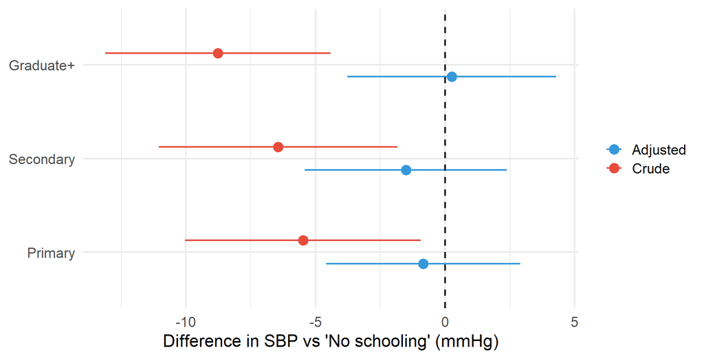

# Dummy coding

## Categorical predictors become 0/1 columns

```r
model.matrix(~ education, data = cc) |> head(6)
```

```
  (Intercept) educationPrimary educationSecondary educationGraduate+
1           1                1                  0                  0
2           1                1                  0                  0
3           1                0                  0                  1
4           1                1                  0                  0
5           1                0                  0                  1
6           1                0                  1                  0
```

- A variable with **k levels** → **k − 1 dummy variables**
- The omitted level is the **reference** (all dummies = 0) — here “No schooling”
- Each coefficient = **difference vs the reference**, holding the other variables constant

## Interpreting each level

```r
tidy(m_adj, conf.int = TRUE) |>
  filter(str_detect(term, "education|phys_act|sex")) |>
  select(term, estimate, conf.low, conf.high, p.value) |>
  mutate(across(where(is.numeric), ~ signif(.x, 2)))
```

```
# A tibble: 6 × 5
  term               estimate conf.low conf.high p.value
  <chr>                 <dbl>    <dbl>     <dbl>   <dbl>
1 sexMale                3.8       1.3      6.3  0.0034
2 educationPrimary      -0.85     -4.6      2.9  0.65
3 educationSecondary    -1.5      -5.4      2.4  0.45
4 educationGraduate+     0.25     -3.8      4.3  0.9
5 phys_actmoderate      -3.4      -6.3     -0.56 0.019
6 phys_acthigh          -5        -7.9     -2.1  0.00075
```

- `sexMale` = **3.8** → men have 3.8 mmHg higher mean SBP than women (reference), all else equal
- `phys_acthigh` = **-5** → high vs **low** activity (the reference)
- Always state the **reference category** when you report a categorical β

## Changing the reference: `relevel()`

```r
cc$education2 <- relevel(cc$education, ref = "Graduate+")
m_adj2 <- lm(sbp ~ salt_g + age + bmi + sex + residence + education2 +
               tobacco + alcohol + phys_act, data = cc)
tidy(m_adj2) |> filter(str_detect(term, "education")) |> mutate(across(where(is.numeric), ~ round(.x, 2)))
```

```
# A tibble: 3 × 5
  term                   estimate std.error statistic p.value
  <chr>                     <dbl>     <dbl>     <dbl>   <dbl>
1 education2No schooling    -0.25      2.05     -0.12    0.9
2 education2Primary         -1.1       1.64     -0.67    0.5
3 education2Secondary       -1.77      1.58     -1.11    0.27
```

```r
c(salt_before = coef(m_adj)[["salt_g"]], salt_after = coef(m_adj2)[["salt_g"]])
```

```
salt_before  salt_after
   1.799679    1.799679
```

Same model, same fit, same salt β — only the **comparison** changes. Choose a reference that is **large**, **clinically meaningful** (e.g. lowest-risk or “usual” group) and **stated in the table footnote**.

# Model-building strategies

## Four ways to choose covariates

| Strategy | Idea | Verdict |
| --- | --- | --- |
| **DAG / theory-driven** | Choose covariates from causal knowledge *before* looking at p-values | ⭐ **Recommended** |
| **Purposeful selection** | Screen, fit, drop, re-check change in β | Acceptable if confounding-focused |
| **Forward / backward / stepwise (AIC)** | Let an algorithm add and drop terms | ⚠️ Exploration only |
| **Univariable p < 0.2 screening** | Keep what is “significant” alone | ⚠️ Avoid (Session 6) |

## Purposeful selection (Hosmer–Lemeshow)

1. Fit each variable **alone**; keep those clinically important or with a liberal p (≈ 0.20–0.25)
2. Fit the **multivariable** model with all of those
3. Remove variables that are non-significant **and** whose removal changes other β by **< 10–20%**
4. **Add back** any variable that changes the exposure β by ≥ 10–20% (confounder)
5. Check **linearity** and plausible **interactions**

It is driven by **change in the exposure β**, not only p-values — better than stepwise, but still data-driven.

## DAG / theory-driven selection — recommended

```
%%{init: {'flowchart': {'nodeSpacing': 25, 'rankSpacing': 55, 'padding': 12, 'htmlLabels': false}, 'themeVariables': {'fontSize': '20px', 'fontFamily': 'Arial, Helvetica, sans-serif'}}}%%
flowchart LR
  Age --> Salt
  Age --> BMI
  Age --> SBP
  Res["Residence"] --> Salt
  Res --> BMI
  BMI --> Salt
  BMI --> SBP
  Sex --> BMI
  Sex --> SBP
  Edu["Education"] --> SBP
  Age --> Edu
  Salt ==> SBP
  Tob["Tobacco,<br/>alcohol, activity"] --> SBP
  classDef conf fill:#fdebd0,stroke:#e67e22,stroke-width:2px;
  classDef exp fill:#d6eaf8,stroke:#3498db,stroke-width:3px;
  classDef out fill:#fadbd8,stroke:#e74c3c,stroke-width:3px;
  classDef prec fill:#eaf2f8,stroke:#85929e,stroke-dasharray: 4 3;
  class Age,BMI,Res,Sex,Edu conf; class Salt exp; class SBP out; class Tob prec;
```

## How theory chooses the model

- **Adjust for** common causes of exposure and outcome (age, sex, residence, BMI-as-confounder, education)
- **Add** outcome-only risk factors (tobacco, alcohol, activity) for **precision**
- **Do not adjust** for **mediators** (on the path salt → … → SBP) or **colliders**
- **Pre-specify** the model in your protocol; report it **regardless of p-values**

That is exactly the “adjusted” model we have been fitting — chosen from the **diagram**, not from the p-values.

## Automated selection: how `step()` works

**Forward**

start empty → add the term that lowers **AIC** most → stop when none helps

**Backward**

start full → drop the term whose removal lowers **AIC** most → stop when none helps

**Both (stepwise)**

at each step consider **adding or dropping** → stop when AIC cannot improve

AIC = fit penalised for number of parameters; **lower is better**. (Same data, same rows in every model!)

## `step()` in R — forward

```r
m_null <- lm(sbp ~ 1, data = cc)
m_full <- lm(sbp ~ salt_g + age + bmi + waist + sex + residence + education +
               tobacco + alcohol + phys_act, data = cc)

fwd <- step(m_null, scope = formula(m_full), direction = "forward", trace = 0)
fwd$anova |> mutate(across(where(is.numeric), ~ round(.x, 1)))
```

```
        Step Df Deviance Resid. Df Resid. Dev    AIC
1            NA       NA       550   160037.5 3127.0
2      + age -1  36412.1       549   123625.4 2986.7
3   + salt_g -1  14100.9       548   109524.5 2922.0
4    + waist -1   5075.4       547   104449.0 2897.8
5  + tobacco -1   1981.0       546   102468.0 2889.3
6 + phys_act -2   1978.7       544   100489.3 2882.5
7      + sex -1   1042.3       543    99447.0 2878.8
8  + alcohol -1    483.3       542    98963.7 2878.1
```

## `step()` in R — backward and both

```r
bwd  <- step(m_full, direction = "backward", trace = 0)
both <- step(m_full, direction = "both",     trace = 0)
bwd$anova |> mutate(across(where(is.numeric), ~ round(.x, 1)))
```

```
         Step Df Deviance Resid. Df Resid. Dev    AIC
1             NA       NA       537    98420.0 2885.1
2 - education  3    273.3       540    98693.3 2880.6
3     - waist  1      2.5       541    98695.8 2878.6
4 - residence  1     27.6       542    98723.4 2876.8
```

## Do they agree?

```r
sel <- list(forward = fwd, backward = bwd, both = both, full = m_full)
map_dfr(sel, ~ {
  tl <- attr(terms(.x), "term.labels")
  tibble(n_terms = length(tl), AIC = round(AIC(.x), 1),
         salt_b = round(coef(.x)[["salt_g"]], 2),
         adiposity_kept = paste(intersect(c("bmi", "waist"), tl), collapse = " + "))
}, .id = "strategy")
```

```
# A tibble: 4 × 5
  strategy n_terms   AIC salt_b adiposity_kept
  <chr>      <int> <dbl>  <dbl> <chr>
1 forward        7 4444.   1.83 waist
2 backward       7 4442.   1.79 bmi
3 both           7 4442.   1.79 bmi
4 full          10 4451.   1.8  bmi + waist
```

**Forward kept `waist`; backward and both kept `bmi`** — near-duplicates. Which “wins” is a coin flip, not science.

## Why automated selection is problematic

**1. Biased β** — selected variables look stronger than they are (winner’s curse)

**2. Too-narrow CIs and p-values too small** — they ignore that you searched

**3. Unstable** — a different sample selects different variables

**4. Ignores confounding logic** — can drop a confounder, keep a mediator, or pick `waist` over `bmi` by chance

Let us *see* 1–3 in our data.

## Demo 1: step() on pure noise

```r
set.seed(1)
noise <- as_tibble(matrix(rnorm(nrow(cc) * 20), ncol = 20, dimnames = list(NULL, paste0("z", 1:20))))
d_n   <- bind_cols(cc |> select(sbp, salt_g, age, bmi), noise)
kept  <- step(lm(sbp ~ ., data = d_n), trace = 0)

tidy(kept) |> filter(str_detect(term, "^z")) |> mutate(across(where(is.numeric), ~ round(.x, 3)))
```

```
# A tibble: 4 × 5
  term  estimate std.error statistic p.value
  <chr>    <dbl>     <dbl>     <dbl>   <dbl>
1 z3      -0.926     0.588     -1.58   0.116
2 z4       0.986     0.54       1.82   0.069
3 z10     -0.9       0.63      -1.43   0.153
4 z17      1.27      0.62       2.05   0.041
```

Twenty **random-number** variables, nothing to find. `step()` kept **4** of them, one with **p = 0.041**. A thesis table built this way reports “significant” noise.

## Demo 2: the selection changes with the sample

```r
set.seed(42)
vars <- c("salt_g", "age", "bmi", "waist", "sex", "residence", "education", "tobacco", "alcohol", "phys_act")
B <- 100
res <- map(seq_len(B), \(i) {
  bs <- cc[sample(nrow(cc), replace = TRUE), ]
  mm <- step(lm(reformulate(vars, "sbp"), bs), trace = 0)
  list(sel = vars %in% attr(terms(mm), "term.labels"),
       alc = if ("alcoholYes" %in% names(coef(mm))) coef(mm)[["alcoholYes"]] else 0)
})
freq <- tibble(variable = vars, selected = rowMeans(sapply(res, `[[`, "sel")))

ggplot(freq, aes(selected, reorder(variable, selected))) +
  geom_col(fill = col_blue) + geom_vline(xintercept = c(.5, 1), linetype = "dashed") +
  scale_x_continuous(labels = scales::percent) +
  labs(x = "% of 100 bootstrap samples in which backward step() kept the variable", y = NULL)
```

## Demo 2: the selection changes with the sample

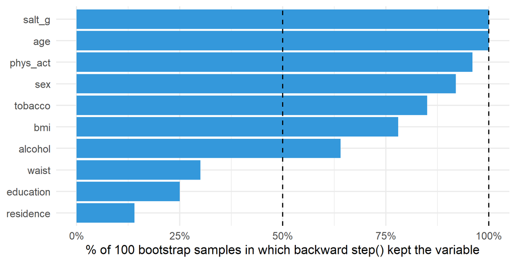

## Demo 3: the β after selection is distorted

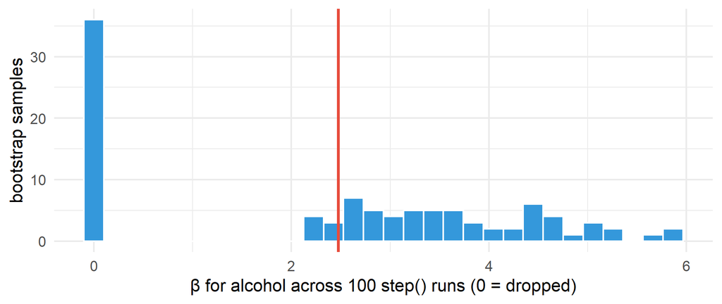

```r
b_alc <- sapply(res, `[[`, "alc")
tibble(beta = b_alc) |>
  ggplot(aes(beta)) +
  geom_histogram(bins = 30, fill = col_blue, colour = "white") +
  geom_vline(xintercept = coef(m_full)[["alcoholYes"]], colour = col_red, linewidth = 1.2) +
  labs(x = "β for alcohol across 100 step() runs (0 = dropped)", y = "bootstrap samples")
```

Red line = full-model β (2.5). Alcohol survived in **64** of 100 runs; **when kept, its average β was 3.7** — inflated; when dropped it is **0**. One “final” model hides all of this, hence **overly narrow CIs**.

## A defensible workflow

1. **Think first** — draw the DAG; list confounders; fix the model in the protocol
2. **Fit** crude and adjusted models; report **both** (`tbl_merge`)
3. **Check assumptions** (Session 4)
4. **Sensitivity**: alternative covariate sets (e.g., swap BMI ↔︎ waist)
5. Use `step()`, if at all, **only to explore** — and say so

## 🔧 Switch to R — Lab 3

**File:** `regression-workshop/labs/lab3_multiple.R`

- `confint()` · crude vs adjusted models · `tbl_regression()` + `tbl_merge()`
- Dummy coding and `relevel()`
- `step()` **forward**, **backward** and **both** — compare the results

**Time:** 45 minutes · answer Q1–Q5 in the comments

## Self-check quiz (1/6)

The salt coefficient has p = 0.0003. Which statement is correct?

- There is a 0.03% chance that the null hypothesis is true
- Data this extreme would be rare if the true β were exactly 0
- Salt explains 99.97% of the variation in systolic pressure
- The effect of salt on blood pressure is clearly clinically important

## Self-check quiz (2/6)

The salt β falls from 3.4 (crude) to 1.8 after adjusting for age, BMI and others. What does this mainly suggest?

- Salt has no effect on systolic pressure at all
- Part of the crude association was due to confounding
- The adjusted model contains too many variables
- The crude model must have contained a calculation error

## Self-check quiz (3/6)

In the adjusted model with low activity as the reference, phys_acthigh = −5.0. What does this mean?

- Each additional hour of weekly activity lowers a person’s SBP by 5.0 mmHg on average
- High-activity adults average 5.0 mmHg less SBP than low-activity ones, others equal
- Physical activity reduces systolic pressure by 5% in everyone who exercises more
- High-activity adults are five times as common as low-activity adults in the sample

## Self-check quiz (4/6)

Which statement about stepwise (AIC) selection is TRUE?

- It identifies the model with the most plausible causal structure in the data
- The final p-values and CIs ignore the search, so they look too optimistic
- It tends to pick the same variables in each resample of the dataset
- It can never remove a variable that confounds the exposure-outcome link

## Self-check quiz (5/6)

An algorithm starts from an intercept-only model, adds the variable that most improves AIC at each step, and stops when none helps. What is this strategy called? (one word)

## Self-check quiz (6/6)

With low activity as reference, phys_actmoderate = −3.4 and phys_acthigh = −5.0. How many mmHg lower is mean SBP in the high group than in the moderate group, all else equal? (1 decimal)

## Score and take-home

**Your score:**

- **p** answers “could this be chance?”; **CI** shows size and precision; ask “is it clinically meaningful?”
- **Confounding**: compare crude vs adjusted β (≥10% change matters)
- **Dummy coding**: k − 1 columns, each vs the **reference** — always name it
- **Choose covariates from theory (DAG)**, not from p-values; `step()` is exploration only

**Next:** Session 4 — are the model’s assumptions believable?